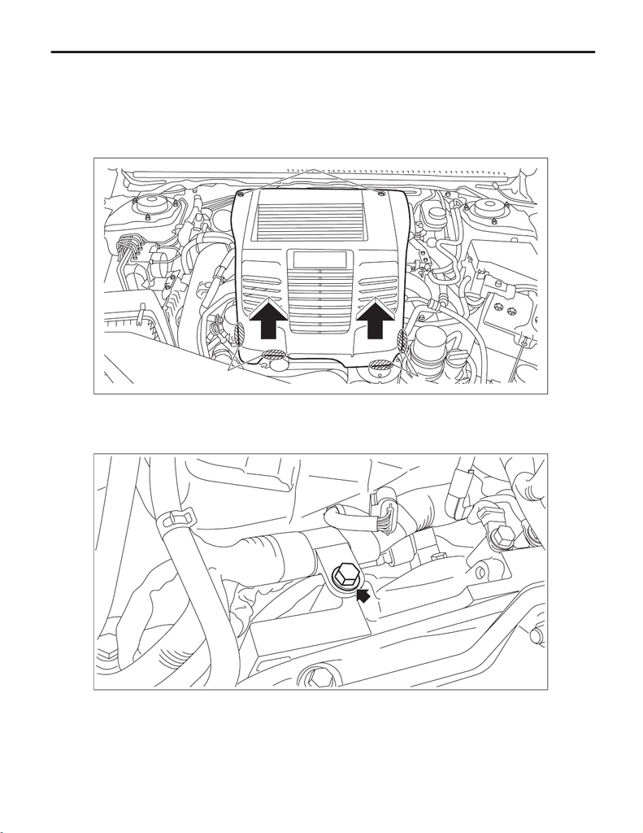

FU(w/o STI)-98

Crankshaft Position Sensor

FUEL INJECTION (FUEL SYSTEMS)

13.Crankshaft Position Sensor

A: REMOVAL

1) Remove the collector cover.

(1) Remove the clips (A).

(2) Hold the shaded area (B) by hand and carefully pull the RH side (C) upward.

(3) Hold the shaded area (D) by hand and carefully pull the LH side (E) upward.

2) Disconnect the ground terminal from battery sensor. <Ref. to NT-5, BATTERY, NOTE, Note.>

3) Remove the intercooler. <Ref. to IN(w/o STI)-38, REMOVAL, Intercooler.>

4) Remove the throttle body. <Ref. to FU(w/o STI)-15, REMOVAL, Throttle Body.>

5) Remove the bolts securing the engine harness.

EX-03204

(A)

(B)

(C)

(E)

(D)

FU-08485

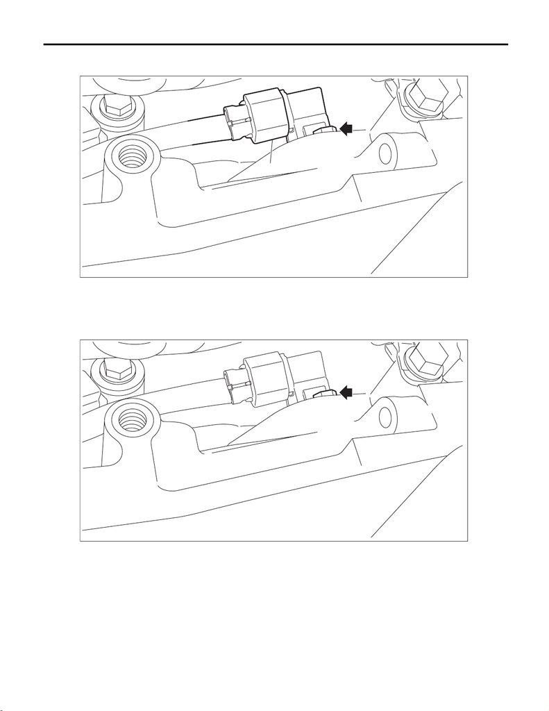

FU(w/o STI)-99

Crankshaft Position Sensor

FUEL INJECTION (FUEL SYSTEMS)

sensor from the cylinder block.

B: INSTALLATION

Install in the reverse order of removal.

Tightening torque:

6.4 N·m (0.7 kgf-m, 4.7 ft-lb)

FU-08486

(A)

FU-08491

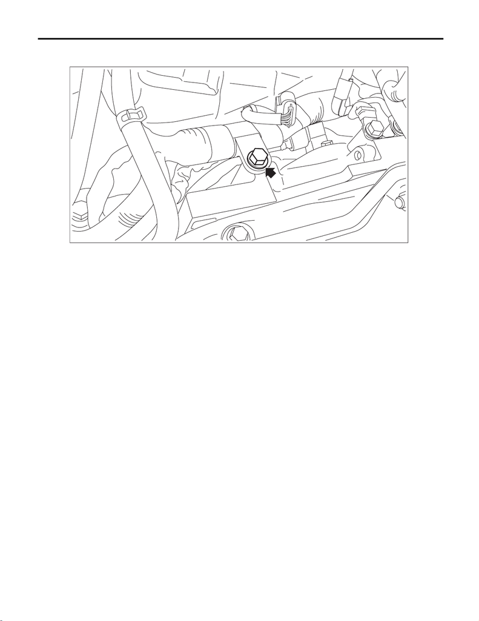

FU(w/o STI)-100

Crankshaft Position Sensor

FUEL INJECTION (FUEL SYSTEMS)

Tightening torque:

19 N·m (1.9 kgf-m, 14.0 ft-lb)

C: INSPECTION

1. CRANKSHAFT POSITION SENSOR (METHOD WITH OSCILLOSCOPE)

1) Disconnect the ground terminal from battery sensor. <Ref. to NT-5, BATTERY, NOTE, Note.>

2) Prepare an oscilloscope.

3) Remove the engine control module (ECM). <Ref. to FU(w/o STI)-132, REMOVAL, Engine Control Module

(ECM).>

4) Install the ST between the ECM and bulkhead harness and the engine harness. <Ref. to EN(w/o STI)(di-

ag)-6, CAUTION, General Description.>

ST 18460AA030 CHECK BOARD

5) Connect the ground terminal to battery sensor. <Ref. to NT-5, BATTERY, NOTE, Note.>

FU-08485

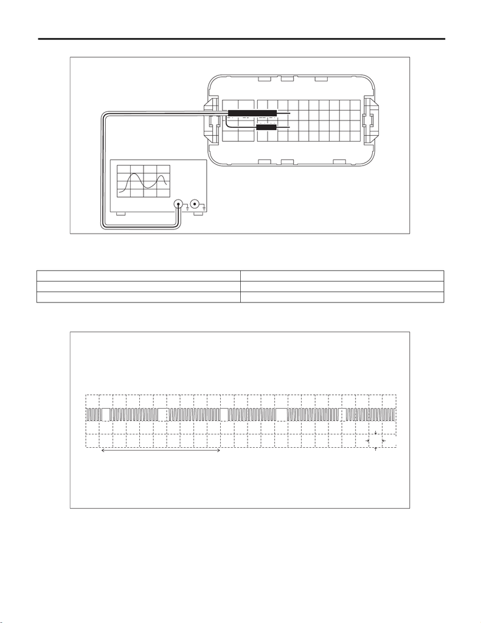

FU(w/o STI)-101

Crankshaft Position Sensor

FUEL INJECTION (FUEL SYSTEMS)

6) Connect the probe to ST.

7) Start the engine and let it idle.

8) Check the pattern is the same as the waveform and voltage shown below.

9) After inspection, install the related parts in the reverse order of removal.

2. OTHER INSPECTIONS

Check that the crankshaft position sensor has no deformation, cracks or other damages.

(A) To the check board connector

(ECM connector)

Terminal No. Probe

19 +

31 –

(A) One crankshaft rotation

FU-07517

(A)

7

9

10

8

5

23

1112

6

19

21

22

20

17

24

4748

18

31

33

34

32

2930

43

45

46

44

4142

3

4

12

15

16

1314

27

28

2526

39

40

3738

FU-07969

0

(A)

5V

10ms